# Homework 3

Model Building, Cross-Validation, and Shrinkage

Author

Rex Green

## Data and Goal

The file `BodyFat.txt` is in the `Data/` folder supplied with this module. Keep the provided folder structure intact so the path `../Data/BodyFat.txt` works from this homework file.

## Setup and Initial Diagnostics

#### 0. Name and reproducibility

Replace `< PUT YOUR NAME HERE >` with your full name and set a seed in the setup chunk.

#### 1. Prepare the data

Read `../Data/BodyFat.txt` into a data frame named `bodyfat_orig`. Remove the `row` column, make sure the result is a plain `data.frame`, and print a summary. Briefly note anything in the summary that deserves attention before modeling.

```r
bodyfat_orig <- read_table("../Data/BodyFat.txt")
bodyfat_orig <- bodyfat_orig |> select(-row) |> as.data.frame()
summary(bodyfat_orig)
```

```
     brozek           age            weight          height
 Min.   : 0.00   Min.   :22.00   Min.   :118.5   Min.   :64.00
 1st Qu.:12.80   1st Qu.:35.50   1st Qu.:158.8   1st Qu.:68.38
 Median :19.00   Median :43.00   Median :176.2   Median :70.00
 Mean   :18.89   Mean   :44.86   Mean   :178.8   Mean   :70.32
 3rd Qu.:24.55   3rd Qu.:54.00   3rd Qu.:196.9   3rd Qu.:72.25
 Max.   :45.10   Max.   :81.00   Max.   :363.1   Max.   :77.75
      neck           chest           abdom
 Min.   :31.10   Min.   : 79.3   Min.   : 69.40
 1st Qu.:36.40   1st Qu.: 94.3   1st Qu.: 84.55
 Median :38.00   Median : 99.6   Median : 90.90
 Mean   :37.98   Mean   :100.8   Mean   : 92.49
 3rd Qu.:39.40   3rd Qu.:105.3   3rd Qu.: 99.20
 Max.   :51.20   Max.   :136.2   Max.   :148.10
```

> The upper quartile is the largest by a wide margin. This is concerning because we cannot yet see whether this is one single outlier or an abnormal (skewed) distribution.

#### 2. Check for influential observations

Fit `brozek ~ age + weight + height + neck + chest + abdom` using `bodyfat_orig` and call it `bodyfat_start_mod`. Use Cook’s distance and any other useful diagnostics to identify influential observations. State which observation concerns you and cite evidence from the diagnostic.

```r
bodyfat_start_mod <- lm(brozek ~ age + weight + height + neck + chest + abdom,
  data = bodyfat_orig)
summary(bodyfat_start_mod)
```

```
Call:
lm(formula = brozek ~ age + weight + height + neck + chest +
    abdom, data = bodyfat_orig)

Residuals:
     Min       1Q   Median       3Q      Max
-11.5811  -3.0358   0.0668   2.8879  10.2828

Coefficients:
              Estimate Std. Error t value Pr(>|t|)
(Intercept) -2.010e+01  1.413e+01  -1.423   0.1561
age          5.010e-03  2.540e-02   0.197   0.8438
weight      -8.733e-02  3.879e-02  -2.251   0.0253 *
height      -1.400e-01  1.520e-01  -0.921   0.3579
neck        -4.421e-01  2.019e-01  -2.189   0.0295 *
chest        4.844e-04  9.107e-02   0.005   0.9958
abdom        8.754e-01  7.924e-02  11.048   <2e-16 ***
---
Signif. codes:  0 '***' 0.001 '**' 0.01 '*' 0.05 '.' 0.1 ' ' 1

Residual standard error: 4.124 on 244 degrees of freedom
Multiple R-squared:  0.722, Adjusted R-squared:  0.7151
F-statistic: 105.6 on 6 and 244 DF,  p-value: < 2.2e-16
```

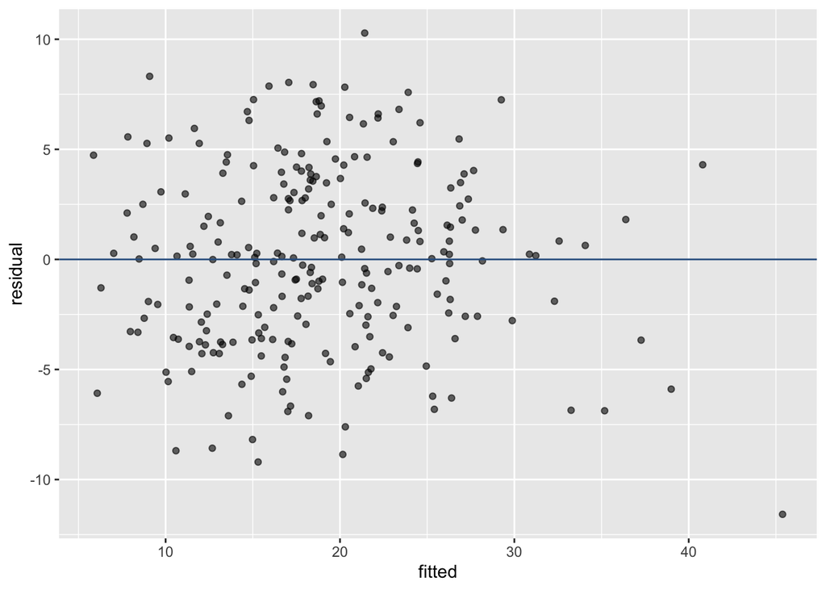

```r
bodyfat_with_resids <- bodyfat_orig |>
  mutate(fitted = fitted(bodyfat_start_mod),
    residual = resid(bodyfat_start_mod))

bodyfat_with_resids |>
  ggplot(aes(x = fitted, y = residual)) +
  geom_point(alpha = .6) +
  geom_hline(yintercept = 0, color = "#2f5f8f")
```

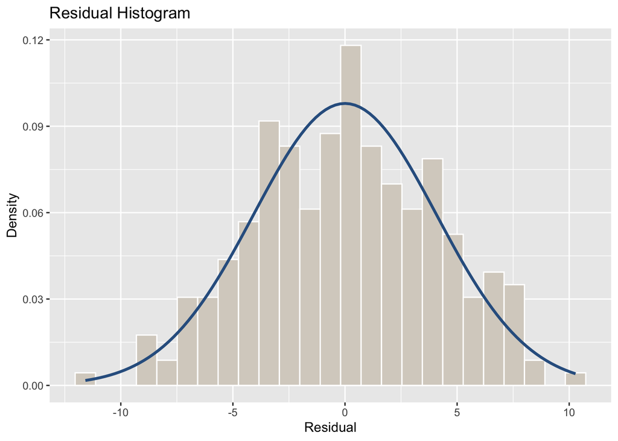

```r
bodyfat_with_resids |>
  ggplot(aes(x = residual)) +
  geom_histogram(aes(y = after_stat(density)), bins = 25,
    fill = "#d7d1c8", color = "white") +
  stat_function(fun = dnorm,
    args = list(mean = mean(bodyfat_with_resids$residual),
      sd = sd(bodyfat_with_resids$residual)),
    color = "#2f5f8f", linewidth = 1.1) +
  labs(x = "Residual" ,y = "Density", title = "Residual Histogram")
```

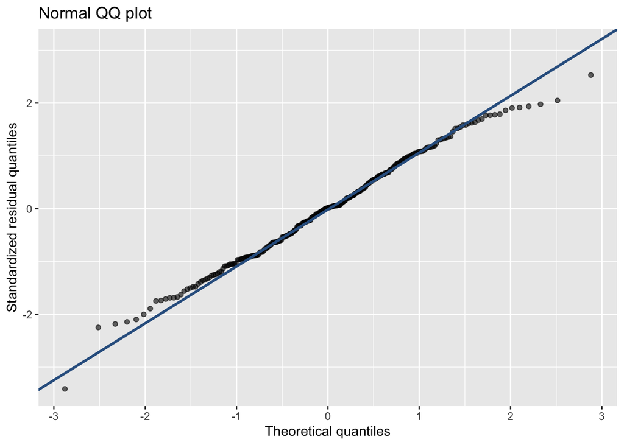

```r
bodyfat_with_resids <- bodyfat_orig |>
  mutate(std_residual = rstandard(bodyfat_start_mod))
ggplot(bodyfat_with_resids, aes(sample = std_residual)) +
  stat_qq(alpha = .6) +
  stat_qq_line(color = "#2f5f8f", linewidth = 1) +
  labs(x = "Theoretical quantiles", y = "Standardized residual quantiles",
    title = "Normal QQ plot")
```

```r
glimpse(sort(hatvalues(bodyfat_start_mod), decreasing = TRUE))
```

```
 Named num [1:251] 0.3227 0.1027 0.0891 0.079 0.0752 ...
 - attr(*, "names")= chr [1:251] "39" "105" "36" "215" ...
```

```r
bodyfat_sorted <- arrange(bodyfat_with_resids, -abs(std_residual))
bodyfat_sorted[1:5, ]
```

```
  brozek age weight height neck chest abdom std_residual
1   33.8  46 363.15  72.25 51.2 136.2 148.1    -3.412337
2   31.7  44 166.00  65.50 39.1 100.6  93.9     2.529789
3    6.1  55 142.25  67.25 35.2  92.7  82.8    -2.248615
4   11.3  55 179.75  68.75 41.1 106.9  95.3    -2.182818
5    1.9  35 125.75  65.50 34.0  90.8  75.0    -2.143015
```

> The observation that concerns me is the observation with brozek 33.8 and standardized residual -3.412. It stands out as a rather extreme outlier on the fitted vs. residual plot (in the bottom right corner), on the far left of the histogram, on the other side of the standardized residual quantiles from the rest of the data in the QQ plot, and we see that its standardized residual is nearly .9 farther from the fitted line than any other observation.

#### 3. Create the analysis data

There is one clearly influential observation. Create a data frame called `bodyfat` that removes it. Use `bodyfat` for the remainder of the assignment.

```r
bodyfat_orig <- arrange(bodyfat_with_resids, -abs(weight))
bodyfat <- bodyfat_orig[-1, -8]  # removes the first row and the residuals
summary(bodyfat)
```

```
     brozek           age            weight          height
 Min.   : 0.00   Min.   :22.00   Min.   :118.5   Min.   :64.00
 1st Qu.:12.80   1st Qu.:35.25   1st Qu.:158.5   1st Qu.:68.31
 Median :19.00   Median :43.00   Median :176.1   Median :70.00
 Mean   :18.83   Mean   :44.86   Mean   :178.1   Mean   :70.31
 3rd Qu.:24.50   3rd Qu.:54.00   3rd Qu.:196.8   3rd Qu.:72.25
 Max.   :45.10   Max.   :81.00   Max.   :262.8   Max.   :77.75
      neck           chest            abdom
 Min.   :31.10   Min.   : 79.30   Min.   : 69.40
 1st Qu.:36.40   1st Qu.: 94.25   1st Qu.: 84.53
 Median :37.95   Median : 99.60   Median : 90.90
 Mean   :37.93   Mean   :100.63   Mean   : 92.27
 3rd Qu.:39.40   3rd Qu.:105.30   3rd Qu.: 99.17
 Max.   :43.90   Max.   :128.30   Max.   :126.20
```

## Multicollinearity

#### 4. Diagnose multicollinearity

Fit `brozek ~ .` on `bodyfat` and call it `bodyfat_full_mod`. Report all VIFs, the maximum VIF, and the mean VIF. Decide whether multicollinearity is a meaningful problem and identify the predictors most responsible. Treat the usual thresholds as rules of thumb, not automatic pass/fail cutoffs.

```r
bodyfat_full_mod <- lm(brozek ~ . , data = bodyfat)
vif(bodyfat_full_mod) |> round(4)
```

```
    age  weight  height    neck   chest   abdom
 1.5408 19.8957  2.6696  3.1246  9.0382  9.7005
```

```r
max(vif(bodyfat_full_mod))
```

```
[1] 19.89574
```

```r
mean(vif(bodyfat_full_mod))
```

```
[1] 7.661578
```

> The maximum VIF is 19.90, for the weight coefficient. The other VIFs are 9.70 for abdomen, 9.03 for chest, 3.12 for neck, 2.66 for heigh, and 1.54 for age, giving a mean VIF is 7.66.  
> I think that multicollinearity is a meaningful problem in this case. The most responsible predictors are weight, abdomen, and chest. This makes sense because extra weight tends to collect near the gut, so the weight, chest, and abdomen are associated with both each other and with higher brozek scores.

#### 5. Connect VIF to coefficient uncertainty

For the predictor with the largest VIF:

1. Fit the auxiliary regression of that predictor on all the other predictors.
2. Use its auxiliary $Rj2$ to calculate $VIFj=1/(1−Rj2)$ by hand.
3. Calculate $VIFj$ and interpret that value as a standard-error inflation factor.

```r
weight_regression <- lm(weight ~ . - brozek, data = bodyfat)
summary(weight_regression)
```

```
Call:
lm(formula = weight ~ . - brozek, data = bodyfat)

Residuals:
     Min       1Q   Median       3Q      Max
-21.4262  -3.5035   0.0161   3.4389  19.1787

Coefficients:
              Estimate Std. Error t value Pr(>|t|)
(Intercept) -296.14459   11.74645 -25.211  < 2e-16 ***
age           -0.28976    0.03327  -8.709 4.70e-16 ***
height         2.78131    0.16551  16.805  < 2e-16 ***
neck           1.91567    0.27371   6.999 2.48e-11 ***
chest          1.13121    0.12430   9.101  < 2e-16 ***
abdom          1.13989    0.09358  12.180  < 2e-16 ***
---
Signif. codes:  0 '***' 0.001 '**' 0.01 '*' 0.05 '.' 0.1 ' ' 1

Residual standard error: 6.125 on 244 degrees of freedom
Multiple R-squared:  0.9497,    Adjusted R-squared:  0.9487
F-statistic: 922.1 on 5 and 244 DF,  p-value: < 2.2e-16
```

```r
weight_r_2 <- .9497
weight_VIF <- 1 / (1 - weight_r_2^2)
sqrt(weight_VIF)
```

```
[1] 3.193244
```

#### 6. Explain the apparent contradiction

A model can have a strong overall $R2$ and useful fitted values while its individual coefficients are unstable because of multicollinearity. Explain why these statements can both be true. Your explanation should use the idea of how much independent information the data contain about each predictor after holding the others fixed.

> These statements are both be true because when we compute the overall $R2$ and the fitted values for the model we choose, those fitted values are interpreted as “holding all other predictors constant”. This becomes a problem in situations where it is difficult to hold other predictors constant (one example would be height and wingspan for basketball players - taller players tend to have larger wingspans). So if we hold height fixed and vary wingspan, the model will tell us that players with larger wingspan tend to be better players, ignoring the fact that height also helps a lot. The data leaves out critical information that helps us to make a decision based on everything we know.

## Model Search: Algorithms and Metrics

#### 7. Best subsets using two metrics

Use `bestglm()` to run best-subsets selection using both AIC and BIC. The response must be the last column. Print the selected formula and model summary for each metric.

```r
bodyfat_bestglm <- bodyfat |> relocate(brozek, .after = last_col())

bestglm(bodyfat_bestglm, IC = "BIC", method = "exhaustive")
```

```
BIC
BICq equivalent for q in (2.1382041714979e-07, 0.623453366900794)
Best Model:
               Estimate Std. Error    t value     Pr(>|t|)
(Intercept) -42.8704030 2.45734997 -17.445787 5.808094e-45
weight       -0.1220605 0.01966474  -6.207072 2.264910e-09
abdom         0.9042642 0.05220553  17.321235 1.542845e-44
```

```r
bestglm(bodyfat_bestglm, IC = "AIC", method = "exhaustive")
```

```
AIC
BICq equivalent for q in (0.765996191927898, 0.895659029345219)
Best Model:
              Estimate Std. Error   t value     Pr(>|t|)
(Intercept)  6.8945747 7.29416317  0.945218 3.454788e-01
height      -0.4466924 0.10406134 -4.292587 2.545425e-05
neck        -0.4847902 0.17997092 -2.693714 7.554405e-03
chest       -0.1438201 0.08160129 -1.762474 7.923620e-02
abdom        0.8258635 0.06055528 13.638175 6.862964e-32
```

#### 8. Interpret AIC, BIC, algorithms, and metrics

Answer each part in complete sentences.

1. Did AIC and BIC select the same model? Explain why they are not required to agree.
2. In the preceding analysis, what was the search algorithm, and what were the two selection metrics?
3. Which metric usually penalizes additional predictors more strongly when $n$ is reasonably large, and what consequence does that tend to have for model size?
> 1. AIC and BIC did not select the same model because they are two different measures that prioritize different aspects. This is acceptable because the two criteria exist to serve different purposes - AIC favors larger models that could have more predictive signals, while BIC favors more interpretable and simpler models.
> 2. In the predicing analysis, the search algorithm was best-subsets selection, and the two selection metrics were AIC and BIC.
> 3. The metric that usually penalizes additional predictors more strongly is BIC. This tend to shrink model size, which improves interpretability but can make reliable prediction more difficult.

#### 9. Explain a limitation of forward selection

Suppose $x1$ is the best one-predictor model, but ${x2,x3}$ is the best two-predictor model according to AIC. Explain why forward selection can fail to reach ${x2,x3}$ even though best subsets can find it. Identify the exact greedy decision that causes the problem.

> Forward selection can fail to reach ${x2,x3}$ because it cannot remove a predictor once it added. The decision to cause the problem is the decision to add $x1$ to the model without checking any other combinations of variables.

## Shrinkage

#### 10. Fit ridge regression and LASSO

Create a predictor matrix containing the six candidate predictors and a separate response vector. Use cross-validated `glmnet()` models to fit:

- ridge regression (`alpha = 0`), and
- LASSO (`alpha = 1`).

For each method, report `lambda.min`, `lambda.1se`, and the coefficients at `lambda.1se`. State how many slope coefficients are exactly zero for each method.

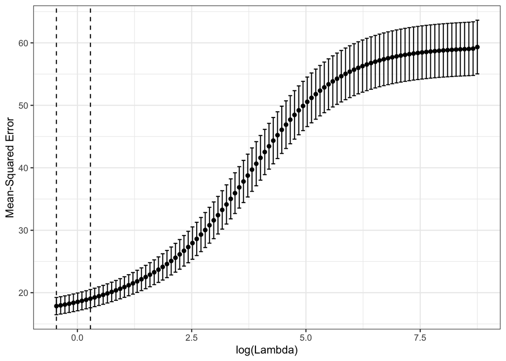

```r
bodyfat_x <- as.matrix(bodyfat_bestglm[ , 1:6])
bodyfat_y <- as.matrix(bodyfat_bestglm[ , 7])

ridge_cv <- cv.glmnet(x = bodyfat_x, y = bodyfat_y, type.measure = "mse", alpha = 0)
autoplot(ridge_cv, label = FALSE) + theme_bw()
```

```r
c(lambda_min = ridge_cv$lambda.min, lambda_1se = ridge_cv$lambda.1se)
```

```
lambda_min lambda_1se
 0.6312929  1.3288110
```

```r
coef(ridge_cv, s = "lambda.1se")
```

```
7 x 1 sparse Matrix of class "dgCMatrix"
             lambda.1se
(Intercept)  1.28714177
age          0.05558329
weight       0.04123839
height      -0.46755150
neck        -0.25216896
chest        0.11664955
abdom        0.41623365
```

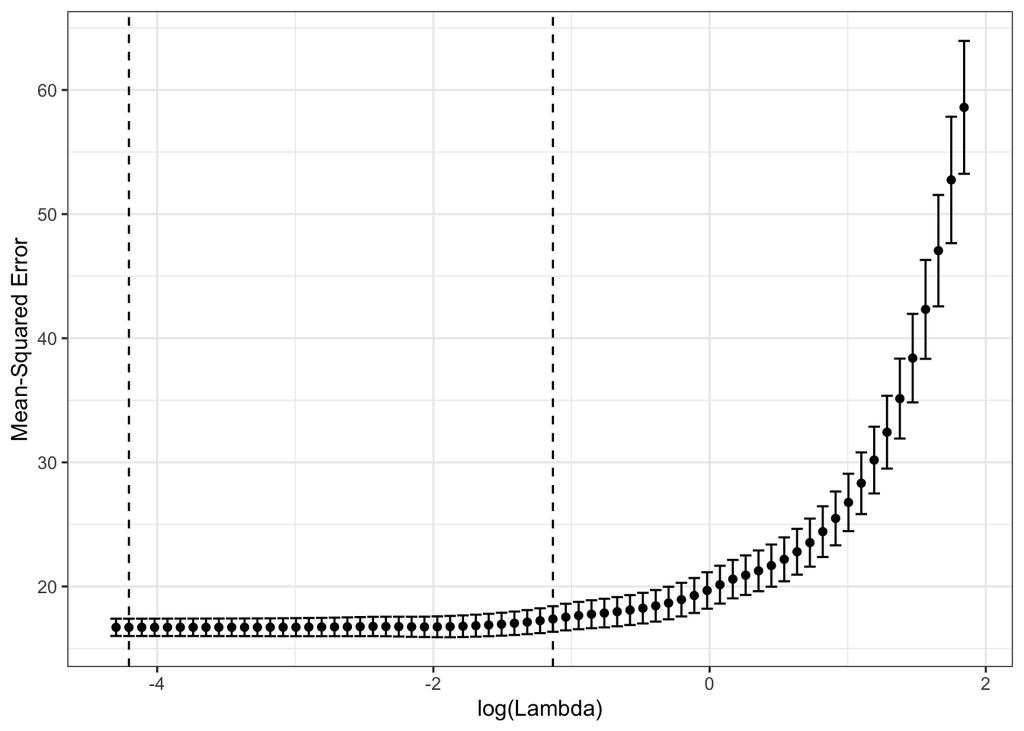

```r
lasso_cv <- cv.glmnet(x = bodyfat_x, y = bodyfat_y, type.measure = "mse", alpha = 1)
autoplot(lasso_cv, label = FALSE) + theme_bw()
```

```r
c(lambda_min = lasso_cv$lambda.min, lambda_1se = lasso_cv$lambda.1se)
```

```
lambda_min lambda_1se
0.01492685 0.32158931
```

```r
coef(lasso_cv, s = "lambda.1se")
```

```
7 x 1 sparse Matrix of class "dgCMatrix"
             lambda.1se
(Intercept) -9.14923265
age          0.01413638
weight       .
height      -0.36234510
neck        -0.12316579
chest        .
abdom        0.62309501
```

#### 11. Explain the bias-variance tradeoff and choose a method

Answer each part in complete sentences.

1. Ridge and LASSO deliberately bias coefficient estimates. Explain how that bias can nevertheless improve prediction on new data.

> The deliberately introduced bias can improve prediction on new data because it also reduces the variance. The coefficients get shrunk towards zero.
2. If only a few of many predictors are believed to matter and interpretability is important, which method is the more natural choice? Why?

> In this case, the more natural choice is LASSO because it will eliminate the predictors that matter less to the model and create a simpler model that is easy to interpret.
3. If many highly correlated predictors each carry some signal and you want them to share credit, which method is often preferable? Why?

> In this case, ridge is often preferable becaues it forces each predictor to have a coefficient, unlike LASSO, which moves more sharply towards 0 and can force predictors to have coefficients of 0.
4. Explain why `lambda.1se` usually produces a simpler model than `lambda.min` while retaining similar estimated predictive performance.

> `lambda.1ase` usually produces a simpler model than `lambda.min` because it is more likely to remove predictors with a higher lambda value, but it still lowers coefficients enough to predict well.

#### 12. Compare selected variables

Fill in the table with an `X` when a variable is included by best subsets or has a nonzero LASSO coefficient at `lambda.1se`.

| Variable | Best Subsets (AIC) | Best Subsets (BIC) | LASSO at `lambda.1se` |
| --- | --- | --- | --- |
| age |  |  | X |
| weight |  | X |  |
| height | X |  | X |
| neck | X |  | X |
| chest | X |  |  |
| abdom | X | X | X |

## Out-of-Sample Model Comparison

#### 13. Compare four candidate models with cross-validation

Compare these four fixed candidate formulas:

1. the full six-predictor model,
2. the formula selected by best subsets using AIC,
3. the formula selected by best subsets using BIC, and
4. an ordinary `lm()` using the predictors with nonzero LASSO coefficients at `lambda.1se`.

Use 5-fold cross-validation repeated 20 times, giving 100 held-out RMSE values for each model. Every fit must use the analysis portion of a split, and every RMSE must use that split’s assessment portion. Report the mean and standard deviation of RMSE for each model, then create side-by-side boxplots of the 100 RMSE values.

When turning a `bestglm` result into a formula for refitting, build a clean formula from the selected predictor names, for example `reformulate(names(coef(best_model))[-1], response = "brozek")`. A formula extracted directly from a `bestglm` fit can retain full-data vectors that do not work inside a resampling fold.

```r
n <- nrow(bodyfat)
rmse_mat <- matrix(NA, nrow = 100, ncol = 4)
colnames(rmse_mat) <- c("full", "aic", "bic", "lasso")

rmse <- function(fit, data) {
  sqrt(mean((predict(fit, data) - data$brozek)^2))
}

row <- 1
for (r in 1:20) {
  folds <- sample(rep(1:5, length.out = n))

  for (k in 1:5) {
    test_data  <- bodyfat[folds == k, ]
    train_data <- bodyfat[folds != k, ]

    full_fit  <- lm(brozek ~ ., data = train_data)
    aic_fit   <- lm(brozek ~ height + neck + chest + abdom,
      data = train_data)
    bic_fit   <- lm(brozek ~ weight + abdom, data = train_data)
    lasso_fit <- lm(brozek ~ age + height + neck + abdom,
      data = train_data)

    rmse_mat[row, "full"]  <- rmse(full_fit, test_data)
    rmse_mat[row, "aic"]   <- rmse(aic_fit, test_data)
    rmse_mat[row, "bic"]   <- rmse(bic_fit, test_data)
    rmse_mat[row, "lasso"] <- rmse(lasso_fit, test_data)

    row <- row + 1
  }
}

# Mean RMSE for each model
colMeans(rmse_mat)
```

```
    full      aic      bic    lasso
4.089701 4.069996 4.090949 4.078719
```

```r
# Standard deviation of RMSE for each model
apply(rmse_mat, 2, sd)
```

```
     full       aic       bic     lasso
0.3039333 0.2981837 0.2968152 0.3153858
```

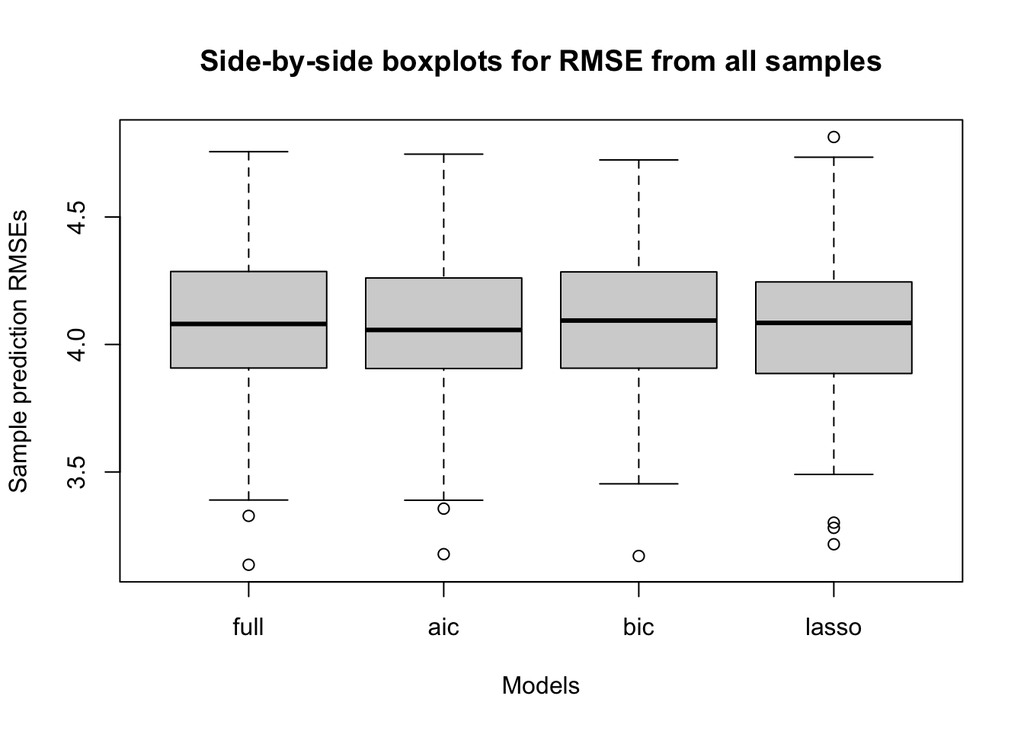

```r
boxplot(rmse_mat,
  main = "Side-by-side boxplots for RMSE from all samples",
  xlab = "Models",
  ylab = "Sample prediction RMSEs")
```

#### 14. Interpret the cross-validation evidence

Answer each part using your numerical results and plot.

1. Which model has the smallest average held-out RMSE?

> The model selected by AIC has the smallest average held-out RMSE, at 4.070.
2. Are the differences in average RMSE large relative to the split-to-split variability? Explain why the smallest displayed average is not automatically a decisive winner.

> The differences in average RMSE are not large relative to the split-to-split variability. We can see from the plots that the smallest RMSE for each of the models falls below 3.5, and the largest for each falls above 4.5, a range of more than 1. However, the differences in average RMSE are less than .03, with the smallest being 4.070 and the largest being 4.090. This suggests that on the average, there is not a large difference in the ability of the models to predict, and that we should look at other criteria to decide which model is best.
3. Why might the full model have the strongest ordinary in-sample $R2$ but fail to have the best cross-validated RMSE?

> The full model might have the strongest ordinary in-sample $R2$ but fail to have the best cross-validated RMSE because it takes into account every single predicto, which boosts $R2$, but might not have the best predictive value.

#### 15. Choose a final model

Choose a final subset of predictors. Defend the choice by reconciling predictive performance, model complexity, multicollinearity, and interpretability. More than one conclusion can earn full credit if the evidence is used carefully.

```r
bodyfat_final_mod <- lm(brozek ~ age + height + neck + abdom, data = bodyfat)
```

## Check the Final Model

For Questions 16-20, use diagnostics appropriate for `final_mod`. For each assumption, show the diagnostic and explain what evidence supports your conclusion.

#### 16. Linearity

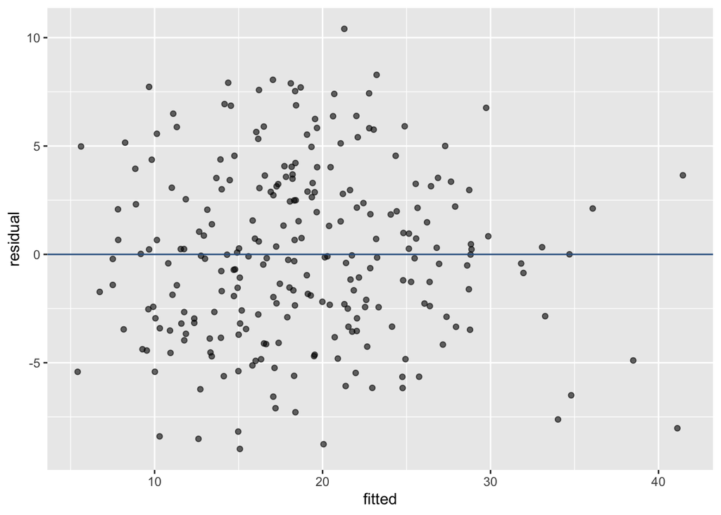

```r
# Get residuals
final_with_resids <- bodyfat |>
  mutate(fitted = fitted(bodyfat_final_mod),
    residual = resid(bodyfat_final_mod))
# residuals vs. fitted plot
final_with_resids |>
  ggplot(aes(x = fitted, y = residual)) +
  geom_point(alpha = .6) +
  geom_hline(yintercept = 0, color = "#2f5f8f")
```

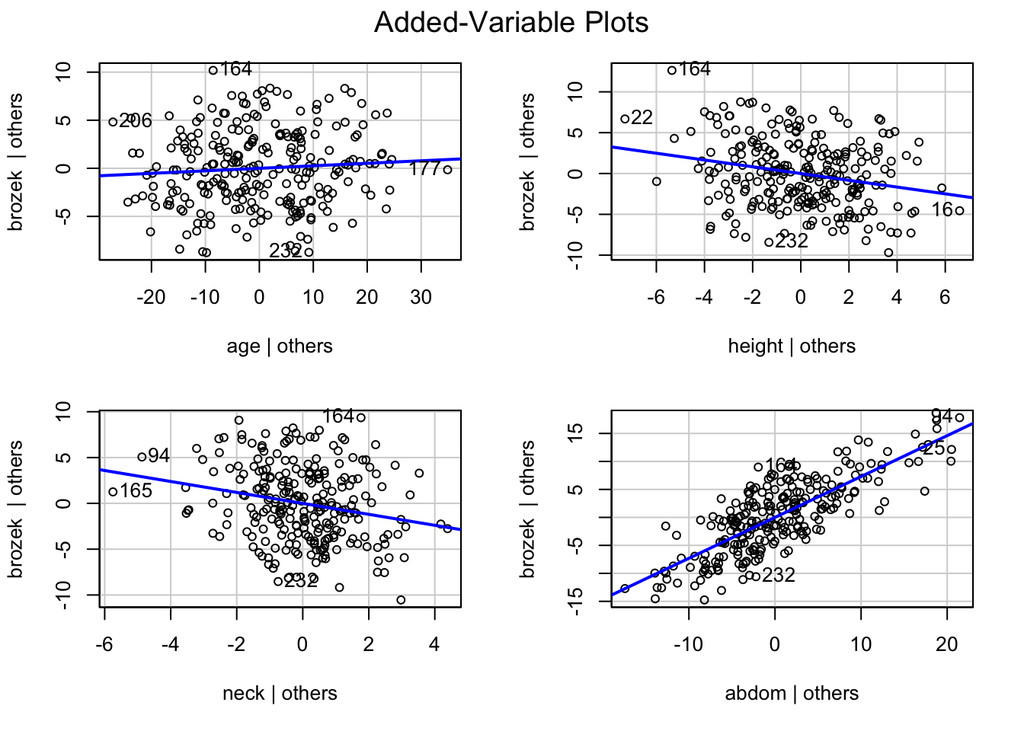

```r
# added-variable plots
avPlots(bodyfat_final_mod, layout = c(2,2))
```

> The residuals vs. fitted plot looks nice, with no curve or trend. The only abnormality is that there are more points on the left side of the graph (with fitted values closer to zero) and a seeming group of outliers scattered on either side of the horizontal line.  
> The added-variable plots, however, do not look great. They do not seem to be very linear at all, except for abdominal circumference. I’m reconsidering: should I have chosen the model with just weight?